# Exercise 9

Author

## Preliminaries

Load the package(s) you need before proceeding:

```r
library(tidyverse)
```

## Task 1-4 Data

survey_responses is a table (data frame) that contains two variables: ParticipantID and Satisfaction. ParticipantID is a unique survey participant identifier ID while Satisfaction represents a survey response about the participant’s satisfaction.

Before proceeding, please run the following:

```r
survey_responses <- read_csv("https://raw.githubusercontent.com/jmtfeliciano/teachingdata/refs/heads/main/survey_responses.csv")
head(survey_responses, 10)
```

```
# A tibble: 10 × 2
   ParticipantID Satisfaction
           <dbl> <chr>
 1             1 Satisfied
 2             2 Neutral
 3             3 Very Dissatisfied
 4             4 Very Satisfied
 5             5 Dissatisfied
 6             6 Neutral
 7             7 Satisfied
 8             8 Dissatisfied
 9             9 Very Satisfied
10            10 Very Dissatisfied
```

## Task 1

Create a bar plot using survey_responses’s Satisfaction variable:

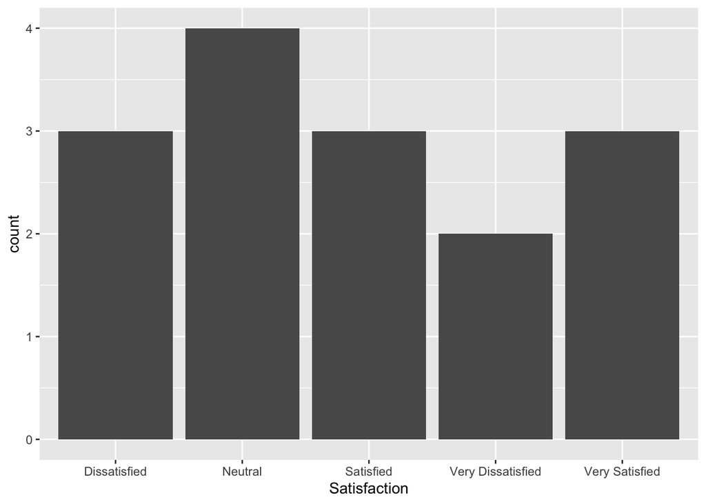

```r
# place your code below
ggplot(survey_responses, aes(x = Satisfaction)) +
  geom_bar()
```

## Task 2

**Prompt:** R when creating geom_bar() sorted the Satisfaction variable alphabetically. Look at the plot you created in Task 1. Does the ordering make sense? If not, what should be the proper ordering from left to right (write down the ordering).

**Your response:** Ordering does not make real sense. You’d want the one with the most negative connotation to the left, and you’d want the one with the most positive connotation to the right.

## Task 3

Using the ordering you determined in Task 2, create a vector called level_vector that contains the proper order for Satisfication.

Using this level_vector, mutate the Satisfication variable or column so it becomes factor with the right ordering. Save this modified data into you R env’t as survey_responses_v2.

```r
# place your code below
level_vector <- c("Very issatisfied", "Dissatisfied", "Neutral", "Satisfied", "Very Satisfied")

survey_responses_v2 <- survey_responses |>
  mutate(Satisfaction = factor(Satisfaction, level = level_vector))
```

## Task 4

Create a bar plot using survey_responses_v2’s Satisfaction variable:

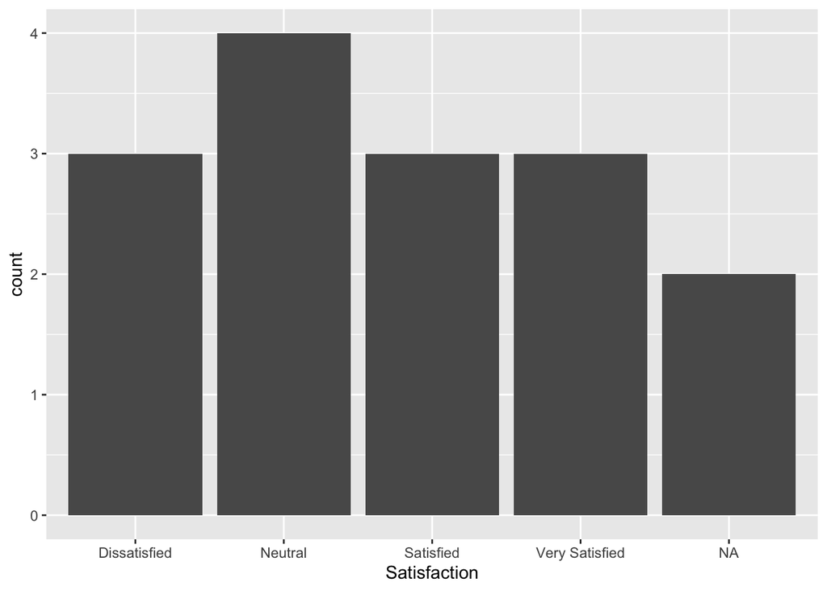

```r
# place your code below
ggplot(survey_responses_v2, aes(x = Satisfaction)) +
  geom_bar()
```

daily_sales is a table that contains daily total sales for the month of October 2024. The data contains the activity date, day (e.g., Tuesday), and sales (which is the total daily sales).

Before proceeding, please run the following:

```r
daily_sales <- read_csv("https://raw.githubusercontent.com/jmtfeliciano/teachingdata/refs/heads/main/daily_sales.csv")
head(daily_sales, 10)
```

```
# A tibble: 10 × 3
   date       day       sales
   <date>     <chr>     <dbl>
 1 2024-10-01 Tuesday    430.
 2 2024-10-02 Wednesday  418.
 3 2024-10-03 Thursday   148.
 4 2024-10-04 Friday     498.
 5 2024-10-05 Saturday   297.
 6 2024-10-06 Sunday     594.
 7 2024-10-07 Monday     165.
 8 2024-10-08 Tuesday    437.
 9 2024-10-09 Wednesday  123.
10 2024-10-10 Thursday   303.
```

## Task 6

Suppose you are interested in analyzing the popularity of each day (e.g., Monday, Sunday) in terms of sales.

Calculate the (1) median day sales and (2) overall total day sales for each day (e.g., Monday, Sunday). Save the resulting table (data frame) as day_analysis. Print a sample of day_analysis using head() or glimpse().

```r
# place your code below
day_analysis <- daily_sales |>
  group_by(day) |>
  summarise(median_day_sales = median(sales, na.rm = T),
            overall_total_sales = sum(sales, na.rm = T))

head(day_analysis, 7)
```

```
# A tibble: 7 × 3
  day       median_day_sales overall_total_sales
  <chr>                <dbl>               <dbl>
1 Friday                152.                928.
2 Monday                261.               1054.
3 Saturday              463.               1701.
4 Sunday                297.               1355.
5 Thursday              268.               1336.
6 Tuesday               247.               1467.
7 Wednesday             252.               1288.
```

## Task 7

Using day_analysis, create a geom_point() plot with x as the median sales and y as the day. Make sure to label the x-axis with “Median sales for October 2024 ($)” and the y-axis as “Day”.

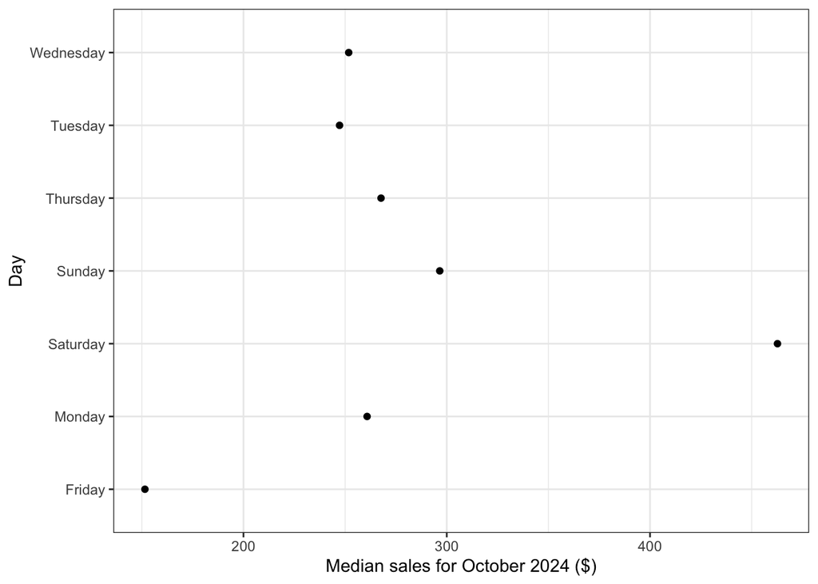

```r
# place your code below
ggplot(day_analysis, aes(x = median_day_sales, y = day)) +
  geom_point() +
  labs(x = "Median sales for October 2024 ($)",
       y = "Day") +
  theme_bw()
```

## Task 8

The plot you created in Task 7 alphabetized the day (from A to Z) which is not the usual ordering of the days within a week. Now, let us convert the day variable into factor with the correct levels.

Using day_analysis, create day_analysis_v2 after converting the day variable into factor with the correct levels. For the purpose of this exercise, start your level with “Monday”.

```r
# place your code below
day_factor <- c("Monday", "Tuesday", "Wednesday", "Thursday", "Friday", "Saturday", "Sunday")

day_analysis_v2 <- day_analysis |>
  mutate(day = factor(day, levels = day_factor))
```

```r
day_analysis_v2 |>
  arrange(day)
```

```
# A tibble: 7 × 3
  day       median_day_sales overall_total_sales
  <fct>                <dbl>               <dbl>
1 Monday                261.               1054.
2 Tuesday               247.               1467.
3 Wednesday             252.               1288.
4 Thursday              268.               1336.
5 Friday                152.                928.
6 Saturday              463.               1701.
7 Sunday                297.               1355.
```

## Task 9

Using day_analysis_v2, create a geom_point() plot with x as the median sales and y as the day. Make sure to label the x-axis with “Median sales for October 2024 ($)” and the y-axis as “Day”. Verify that the days on the y-axis is printed in the expected order.

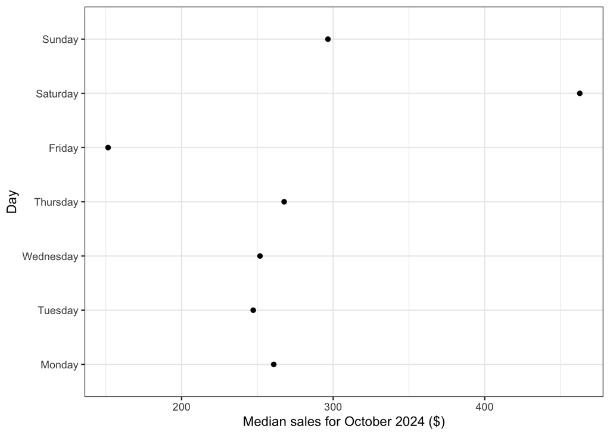

```r
# place your code below
ggplot(day_analysis_v2, aes(x = median_day_sales, y = day)) +
  geom_point() +
  labs(x = "Median sales for October 2024 ($)",
       y = "Day") +
  theme_bw()
```

## Task 10

Using day_analysis_v2, create a geom_point() plot with x as the median sales and y as the day. Make sure to label the x-axis with “Median sales for October 2024 ($)” and the y-axis as “Day”.

This time, however, use fct_reorder() to order the days within your plot based on which days have the highest values for median_day_sales.

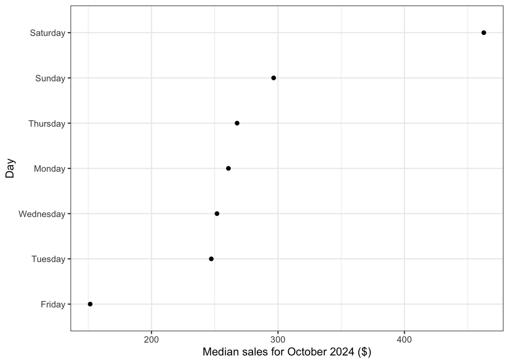

```r
# place your code below
ggplot(day_analysis_v2, aes(x = median_day_sales,
                            y = fct_reorder(day, median_day_sales))) +
  geom_point() +
  labs(x = "Median sales for October 2024 ($)",
       y = "Day") +
  theme_bw() # optional. Also taught you theme_minimal() to remove ugly grey background
```

## Task 11

Using daily_sales, use day with fct_recode to recode day as either Weekend or Weekday. Monday-Friday should be re-coded as “Weekday” while Saturday-Sunday should be re-coded as “Weekend”. Save the resulting recoded table (data frame) as day_analysis_v3 in your R environment. Print a sample of day_analysis_v3 using head() or glipmse() below too.

```r
# place your code below
day_analysis_v3 <- daily_sales |>
  mutate(day = fct_recode(day,
                          "Weekend" = "Sunday",
                          "Weekend" = "Saturday",
                          "Weekday" = "Monday",
                          "Weekday" = "Tuesday",
                          "Weekday" = "Wednesday",
                          "Weekday" = "Thursday",
                          "Weekday" = "Friday"
                          ))

head(day_analysis_v3)
```

```
# A tibble: 6 × 3
  date       day     sales
  <date>     <fct>   <dbl>
1 2024-10-01 Weekday  430.
2 2024-10-02 Weekday  418.
3 2024-10-03 Weekday  148.
4 2024-10-04 Weekday  498.
5 2024-10-05 Weekend  297.
6 2024-10-06 Weekend  594.
```

```r
# easier with case_when which we learned last week
daily_sales |>
  mutate(day = case_when(
    day %in% c("Monday", "Tuesday", "Wednesday", "Thursday", "Friday") ~ "Weekday",
    day %in% c("Sunday", "Saturday") ~ "Weekend"
    ))
```

```
# A tibble: 31 × 3
   date       day     sales
   <date>     <chr>   <dbl>
 1 2024-10-01 Weekday  430.
 2 2024-10-02 Weekday  418.
 3 2024-10-03 Weekday  148.
 4 2024-10-04 Weekday  498.
 5 2024-10-05 Weekend  297.
 6 2024-10-06 Weekend  594.
 7 2024-10-07 Weekday  165.
 8 2024-10-08 Weekday  437.
 9 2024-10-09 Weekday  123.
10 2024-10-10 Weekday  303.
# ℹ 21 more rows
```

## Task 12-13 Data

diagnosis_table is a table (data frame) containing patient records from 100 patients. For the purpose of this exercise, pay close attention to diagnosis. Before proceeding, run the script below and pay quick attention to the printed data.

```r
diagnosis_table <- read_csv("https://raw.githubusercontent.com/jmtfeliciano/teachingdata/refs/heads/main/medical_data_rare_diagnosis.csv")
head(diagnosis_table)
```

```
# A tibble: 6 × 6
  diagnosis       age gender hospital_visit_count severity treatment_type
  <chr>         <dbl> <chr>                 <dbl> <chr>    <chr>
1 Heart Disease    45 Female                    6 Moderate Therapy
2 Cancer           70 Female                    4 Moderate Observation
3 Liver Disease    44 Female                    9 Moderate Medication
4 COPD             38 Male                      1 Moderate Medication
5 Stroke           40 Male                      2 Severe   Surgery
6 Ebola            50 Male                      6 Moderate Therapy
```

## Task 12

Suppose you are interested to see which diagnosis are rare in your patient population. Use dplyr’s count() or summarize() with diagnosis_table’s diagnosis to print the number of patients with each unique diagnosis. Make sure to print the diagnosis counts in ascending order.

```r
# place your code below
diagnosis_table |>
  count(diagnosis) |>
  arrange(n)
```

```
# A tibble: 18 × 2
   diagnosis          n
   <chr>          <int>
 1 Chikungunya        1
 2 Ebola              1
 3 MERS               1
 4 Malaria            1
 5 SARS               1
 6 Zika               1
 7 COPD               3
 8 Diabetes           5
 9 Heart Disease      5
10 Hypertension       7
11 Kidney Disease     7
12 Pneumonia          7
13 Stroke             7
14 Flu                8
15 Asthma            10
16 Liver Disease     10
17 Cancer            12
18 Arthritis         13
```

## Task 13

Using diagnosis_table and fct_lump_n(), recode diagnosis (those only appearing once) as “Other” below. Make sure to print the resulting table below.

```r
# place your code below
diagnosis_table |>
  mutate(diagnosis = fct_lump_n(diagnosis, 2))
```

```
# A tibble: 100 × 6
   diagnosis   age gender hospital_visit_count severity treatment_type
   <fct>     <dbl> <chr>                 <dbl> <chr>    <chr>
 1 Other        45 Female                    6 Moderate Therapy
 2 Cancer       70 Female                    4 Moderate Observation
 3 Other        44 Female                    9 Moderate Medication
 4 Other        38 Male                      1 Moderate Medication
 5 Other        40 Male                      2 Severe   Surgery
 6 Other        50 Male                      6 Moderate Therapy
 7 Other        48 Male                      5 Mild     Medication
 8 Other        28 Male                      2 Moderate Observation
 9 Arthritis    38 Male                      6 Severe   Observation
10 Other        45 Male                      1 Mild     Therapy
# ℹ 90 more rows
```